# Bioestadística con R

## Clase 2: Estadística descriptiva

## Variable

Una **variable** es una característica de una persona o de un objeto a la que se le puede asignar un número o categoría.

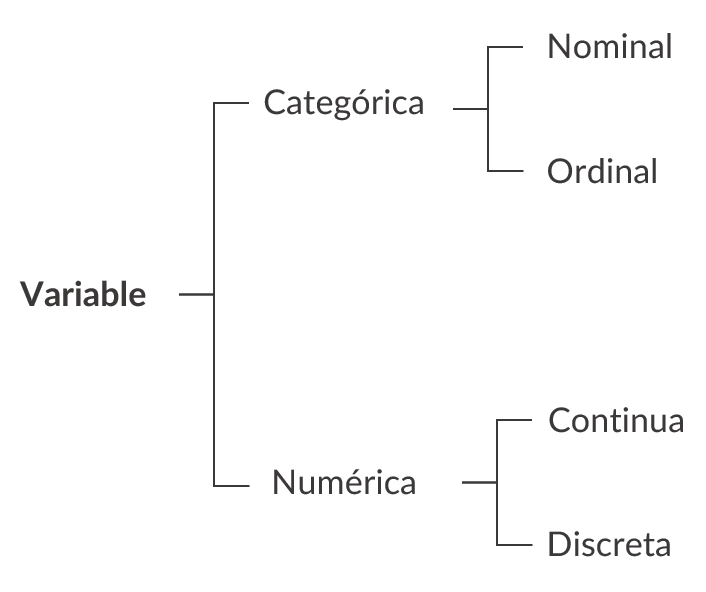

## Unidades observacionales

Cuando colectamos una muestra de \(n\) cosas y medimos una o más variables, llamamos a esas cosas o individuos **unidades observacionales.**

Denotamos a las variables con una letra mayúscula (ej. \(X\)) y las observaciones con letras minúsculas (ej. \(x\)).

## Distribuciones de frecuencia

Nos muestran la **frecuencia** de cada uno de los valores de nuestros datos. Normalmente esta información es presentada en un **gráfico de barras** (para datos categóricos) o un **histograma** (para datos continuos).

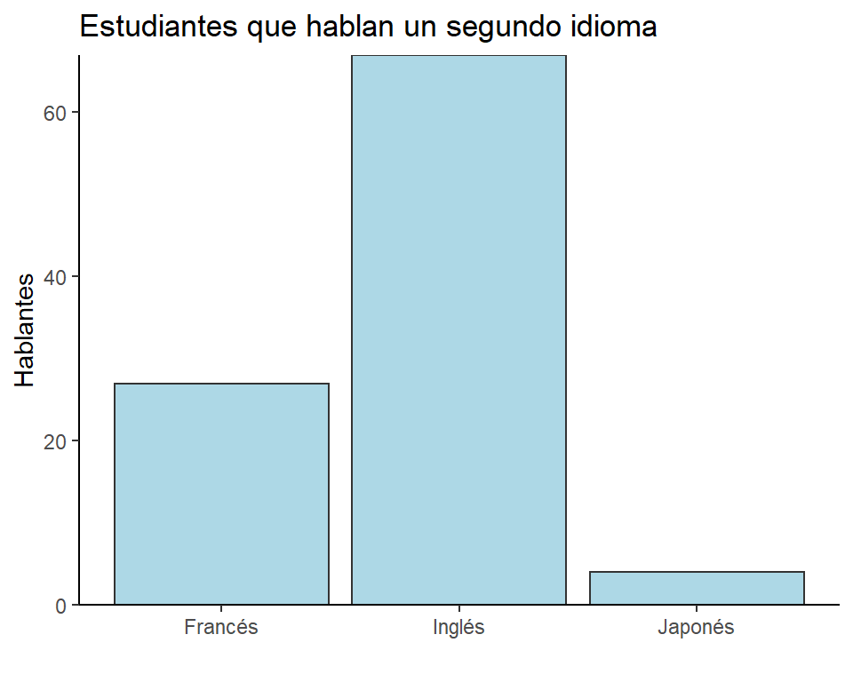

## Distribuciones de frecuencias

Para una variable categórica ordinal…

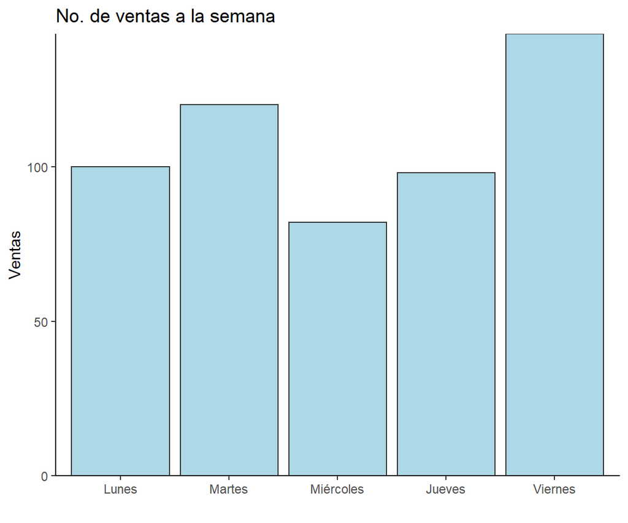

## Distribuciones de frecuencias

Los histogramas son muy parecidos a los gráficos de barras, pero muestran variables numéricas en lugar de categóricas…

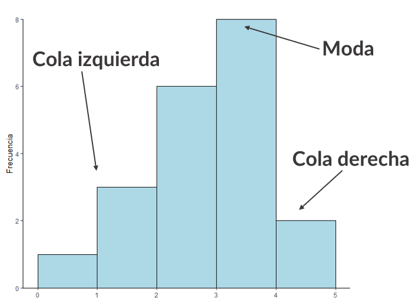

## Datos y estudios

Repasemos un poco conceptos básicos:

- **Estadístico:** medición numérica tomada a partir de una muestra y que describe alguna característica de la misma.
- **Parámetro:** valor numérico que describe algunas características de una población.

## ¿Cuál es la diferencia entre una *población* y una *muestra?*

## Poblaciones y muestras

La **población** es el conjunto total de datos, mientras que una **muestra** es un subconjunto de datos tomados de una población.

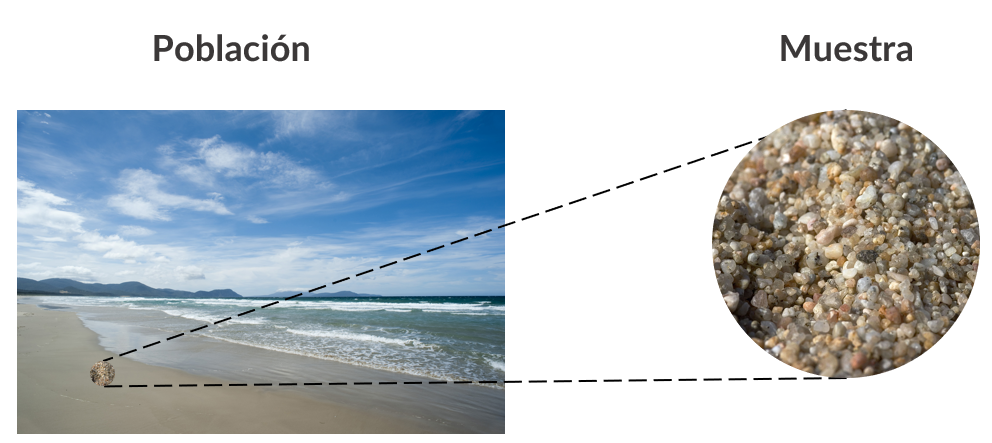

## Poblaciones y muestras

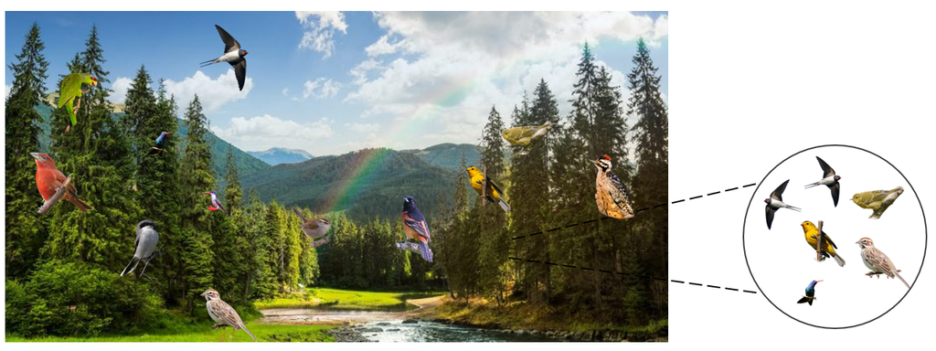

## Tipos de estudio

Los **estudios experimentales** son aquellos en los que el investigador aplica un tratamiento a un conjunto de objetos o individuos, que se conocen como **unidades experimentales.**

En cambio, en un **estudio observacional,** medimos y registramos características pero no modificamos a los objetos estudiados.

## Medidas de tendencia central

## Medidas de tendencia central

Sirven para describir los valores del centro o valores medios de algún conjunto de datos. Las tres medidas de tendencia central más utilizadas son:

- **Media**
- **Mediana**
- **Moda**

## Media

Mide el promedio del valor de nuestros datos. Se calcula como la suma de los valores de las observaciones dividida entre el número de observaciones.

**Muestral:** \[ \overline{x} = \frac{\sum_{i = 1}^{n}{x_i}}{n} \]

**Poblacional:** \[ \mu = \frac{\sum_{i = 1}^{N}{x_i}}{N} \]

## Propiedades de la media

- No es un estadístico **robusto.**
- Utiliza los valores de todos los datos disponibles.
- La media muestral (\(\overline{x}\)) de una población tiende a variar menos que otras medidas de tendencia central.

> **Ejemplo:** En un experimento se administraron distintos tratamientos a un grupo de plantas y se midió el peso seco de todas ellas. Supongamos que queremos saber cuál fue la media del grupo control (usar base de datos PlantGrowth).

## Media

```r
data("PlantGrowth")
head(PlantGrowth)
```

```
##   weight group
## 1   4.17  ctrl
## 2   5.58  ctrl
## 3   5.18  ctrl
## 4   6.11  ctrl
## 5   4.50  ctrl
## 6   4.61  ctrl
```

## Media

Filtramos los datos para solamente tener los valores del grupo control. Los corchetes sirven para seleccionar datos en formato [filas, columnas].

```r
control <- PlantGrowth[0:10,1]
control
```

```
##  [1] 4.17 5.58 5.18 6.11 4.50 4.61 5.17 4.53 5.33 5.14
```

## Media

```r
mean(control)
```

```
## [1] 5.032
```

## Mediana

Es el valor que se encuentra justo por la mitad de la distribución de nuestros datos. Se representa con el símbolo \(\tilde{x}\) (léase \(x\) tilde).

\[ 1, \space 2, \space 3, \space 4, \space 5 \]

La mediana correspondería al valor de en medio, que en este caso es 3.

```r
median(c(1,2,3,4,5))
```

```
## [1] 3
```

## Mediana

En caso de tener un número par de observaciones, la mediana se puede calcular como un promedio de los dos valores centrales.

\[ 5, \space 6, \space 7, \space 8, \space 9, \space 10 \]

```r
median(c(5, 6, 7, 8, 9, 10))
```

```
## [1] 7.5
```

En este caso, la media se calculó así…

\[ \tilde{x} = \frac{7+8}{2} = 7.5 \]

## Mediana

En el caso de la mediana del grupo control de plantas… Primero podemos ajustar nuestros datos de menor a mayor con la función **sort().**

```r
sort(control)
```

```
##  [1] 4.17 4.50 4.53 4.61 5.14 5.17 5.18 5.33 5.58 6.11
```

Al ser número par de observaciones la mediana será el resultado del promedio de los dos valores centrales.

```r
median(control)
```

```
## [1] 5.155
```

## Propiedades de la mediana

- No cambia al añadir valores extremos. Es un estadístico **robusto.**
- No utiliza todo el conjunto de datos.

## Media y mediana

```r
#Genera 100 observaciones aleatorias
set.seed(123)
x <- round(rnorm(100, 5, 2))

mean(x)
```

```
## [1] 5.21
```

```r
median(x)
```

```
## [1] 5
```

## Media y mediana

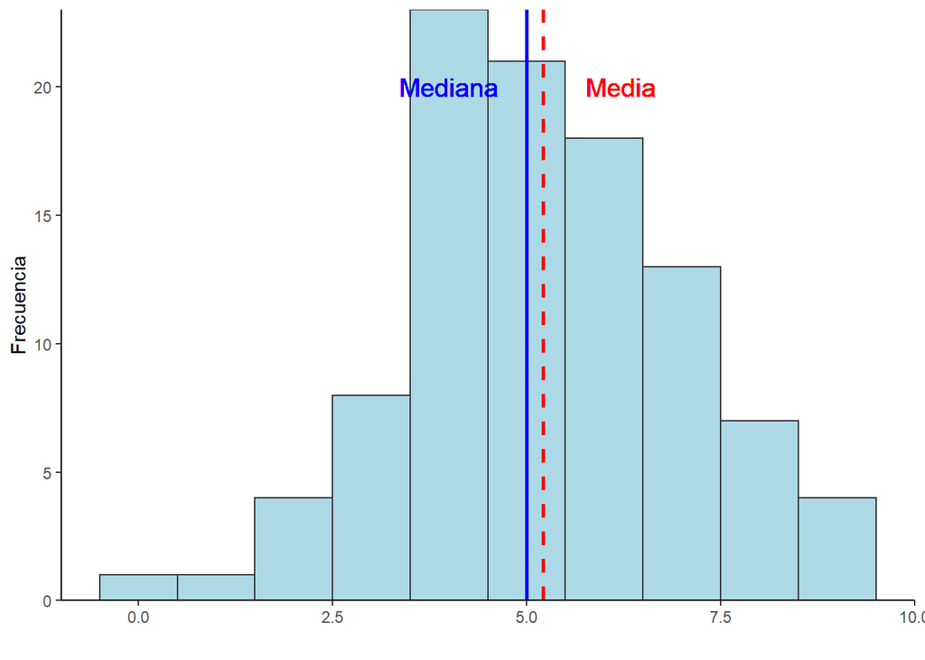

## Moda

Es el valor que más se repite en un conjunto de datos.

Propiedades de la moda:

- Se puede aplicar a datos cualitativos.
- Puede existir una moda (unimodal), dos modas (bimodal), múltiples modas (multimodal) o ninguna moda.

Como tal no existe una función que calcule la moda pero en varias páginas y foros como [StackOverflow](https://stackoverflow.com/) se pueden encontrar scripts para su cálculo.

## Medidas de dispersión

## Medidas de dispersión

A diferencia de los estadísticos de tendencia central, los estadísticos de dispersión describen en cómo se distribuyen los datos. Las medidas que veremos son:

- Rango
- Desviación estándar (\(s\))

## Rango

Corresponde a los valores inferiores y superiores de nuestros datos. Utilizamos la función **range().**

```r
range(control)
```

```
## [1] 4.17 6.11
```

Sin embargo esta función solamente nos otorga el valor máximo y mínimo. Para calcular nuestro rango…

```r
max(control) - min(control)
```

```
## [1] 1.94
```

## Desviación estándar

Mide qué tanto se desvían los valores de los datos de la media. Es representada por el símbolo \(s\) para datos muestrales y \(\sigma\) para datos poblacionales.

**Muestral:** \[ s = \sqrt{\frac{\sum_{i = 1}^{n}( {x_i-\overline{x} ) ^2}}{n-1}} \]

**Poblacional:** \[ \sigma = \sqrt{\frac{\sum_{i = 1}^{N}( {x_i-\overline{x} ) ^2}}{N}} \]

## Desviación estándar

La operación \(x_i - \overline{x}\) corresponde a la **desviación** de nuestros datos respecto de la media.

Para nuestras 100 observaciones aleatorias…

## Desviación estándar

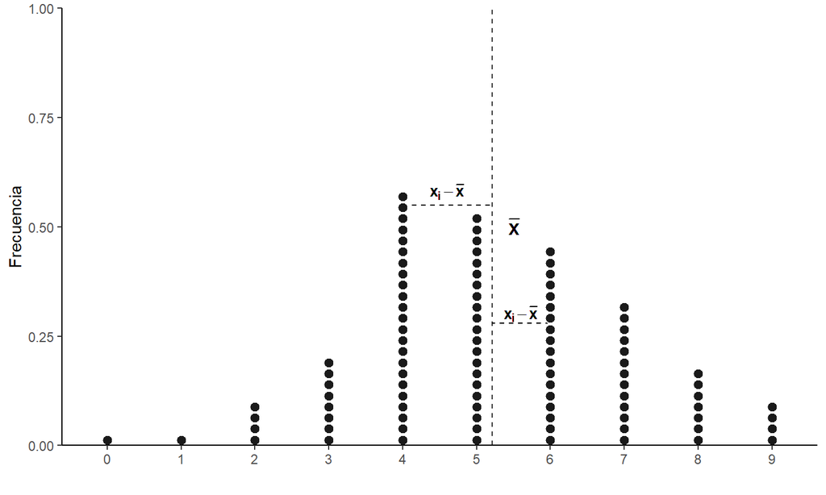

## Desviación estándar

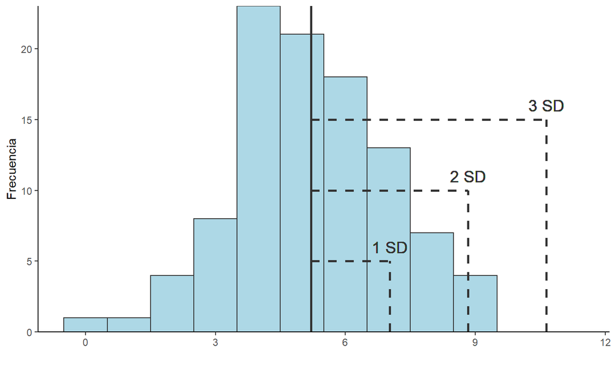

## Propiedades de la desviación estándar

- Nunca tiene un valor negativo.
- Un valor elevado en \(s\) indica mayor dispersión en los datos.
- Puede aumentar considerablemente con valores atípicos, es decir, no es una medida robusta.
- Las unidades de la desviación estándar son iguales a las unidades de los datos originales.

## Desviación estándar

Para los datos de control…

```r
sd(control)
```

```
## [1] 0.5830914
```

## Varianza

Corresponde a la desviación estándar elevada al cuadrado.

\[ s^2 \\ \sigma^2 \]

Propiedades de la varianza:

- Unidades elevadas al cuadrado.
- No es un estadístico robusto.
- Nunca tiene valores negativos.

## Coeficiente de variación

Mide en forma de porcentaje qué tanto varían los datos.

\[ CV = \frac{s}{\overline{x}} \times 100 \]

Para los datos de control…

```r
sd(control)/mean(control)*100
```

```
## [1] 11.58767
```

## Medidas de posición relativa

## Medidas de posición relativa

Indican la posición relativa un dato respecto de los demás datos. Algunas de las medidas más usadas son:

- Valores \(Z\)
- Frecuencia absoluta
- Frecuencia relativa
- Cuartiles

## Valores \(Z\)

Se obtienen al estandarizar los valores de nuestros datos. Es el número de desviaciones estándar (\(s\)) a las que se encuentra un valor dado.

**Muestral:** \[ z = \frac{x_i - \overline{x}}{s} \]

**Poblacional:** \[ Z = \frac{X - \mu}{\sigma} \]

## Propiedades de los valores \(Z\)

- No tienen unidades de medida. Son **adimensionales.**
- Si un valor es menor que la media (\(\overline{x}\)) su valor \(z\) será negativo.

## Valores \(Z\)

Utilizamos la función **scale().**

```r
z <- scale(control)
z
```

```
##             [,1]
##  [1,] -1.4783275
##  [2,]  0.9398184
##  [3,]  0.2538196
##  [4,]  1.8487668
##  [5,] -0.9123784
##  [6,] -0.7237288
##  [7,]  0.2366696
##  [8,] -0.8609285
##  [9,]  0.5110691
## [10,]  0.1852197
## attr(,"scaled:center")
## [1] 5.032
## attr(,"scaled:scale")
## [1] 0.5830914
```

## Frecuencia absoluta

Es el número total de observaciones.

```r
table(control)
```

```
## control
## 4.17  4.5 4.53 4.61 5.14 5.17 5.18 5.33 5.58 6.11
##    1    1    1    1    1    1    1    1    1    1
```

## Frecuencia relativa

Es el valor relativo de cada dato respecto del total. Si se le multiplica por 100% se obtiene su valor en porcentaje.

\[ f_i = \frac{n_i}{N} \]

```r
prop.table(control)
```

```
##  [1] 0.08286963 0.11089030 0.10294118 0.12142289 0.08942766 0.09161367
##  [7] 0.10274245 0.09002385 0.10592210 0.10214626
```

## Cuartiles

Son medidas que dividen el conjunto de datos en cuatro grupos, con 25% de los valores en cada uno de ellos. Se representan por los símbolos \(Q_1\), \(Q_2\) y \(Q_3\), para el primer, segundo y tercer cuartil. \(Q_2\) es equivalente a la mediana (\(Q_2 = \tilde{x}\)).

Existen otros estadísticos que pueden ser calculados a partir de los cuartiles como el Rango Intercuartil (\(IQR\)) como se indica en la siguiente fórmula.

\[ IQR = Q_3 - Q_1 \]

## Cuartiles

Para los datos del grupo control…

```r
summary(control)
```

```
##    Min. 1st Qu.  Median    Mean 3rd Qu.    Max.
##   4.170   4.550   5.155   5.032   5.293   6.110
```

A partir de estos datos nosotros podemos construir un **gráfico de cajas.**

## Valores atípicos

Son aquellos valores que se encuentran por encima o debajo de un umbral establecido por la siguientes formulas:

\[ Q_3 + 1.5 \times IQR \\ Q_1 - 1.5 \times IQR \]

Con estos valores se pueden realizar **gráficas de cajas modificadas.**

## Gráficos de cajas modificadas

Para realizar estas gráficas utilizaremos la librería **ggplot2** que está incluido en el paquete **tidyverse.**

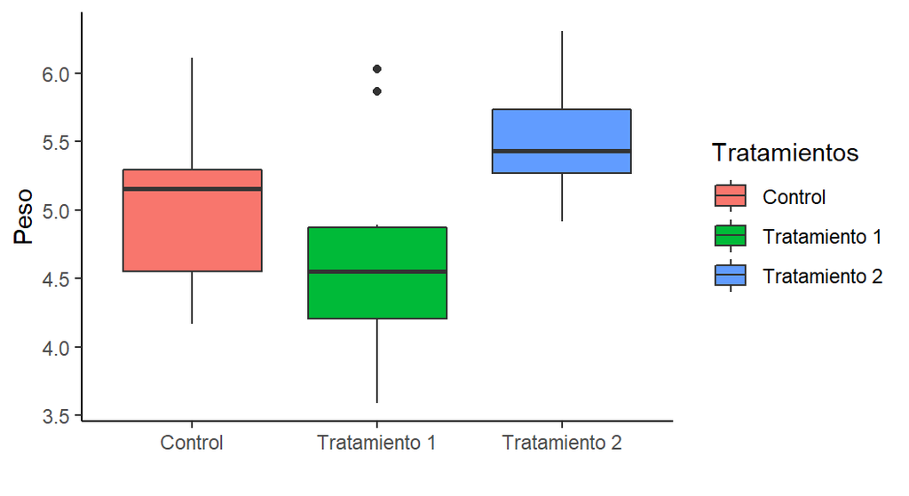

```r
library(tidyverse)
ggplot(data = PlantGrowth) +
  geom_boxplot(aes(x = group, y = weight, fill = group)) +
  xlab("") +
  ylab("Peso") +
  scale_x_discrete(labels = c("Control", "Tratamiento 1", "Tratamiento 2")) +
  scale_fill_discrete(name = "Tratamientos", labels = c("Control", "Tratamiento 1", "Tratamiento 2")) +
  theme_classic()
```

## El uso de **dplyr**

Podemos facilitarnos la vida muchísimo si utilizamos el paquete **dplyr** incluido en el **tidyverse.**

```r
library(dplyr)
```

Las funciones principales de este paquete son:

- **group_by:** agrupa datos.
- **summarize** o **summarise:** resumen de datos agrupados.
- **filter:** encuentra filas con ciertas condiciones.
- **select:** junto a ‘starts_with’, ‘ends_with’ o ‘contains’
- **mutate:** genera nuevas variables.
- **%>%:** pipeline.
- **arrange:** ordena.
- **rename:** renombra columnas.

## group_by

Agrupa nuestros datos dependiendo de alguna variable que asignemos.

```r
Plant_Ordenado <- group_by(PlantGrowth, group)
```

## summarize o summarise

Crea un nuevo data frame con una o más columnas para una combinación de variables. Se utiliza en conjunto con **group_by().**

```r
Plant_Resumen <- summarise(Plant_Ordenado, Media = mean(weight),
                           Mediana = median(weight),
                           Desviacion_estandar = sd(weight),
                           Varianza = var(weight),
                           IQR = IQR(weight),
                           Observaciones = n())
```

## summarize o summarise

```r
Plant_Resumen2 <- summarise(PlantGrowth, Media = mean(weight),
                           Mediana = median(weight),
                           Desviacion_estandar = sd(weight),
                           Varianza = var(weight),
                           IQR = IQR(weight),
                           Observaciones = n())
```

## %>% pipeline

Podemos utilizar esto para realizar varias operaciones en cadena…

```r
Plant_Resumen <- PlantGrowth %>%
  group_by(group) %>%
  summarise(Media = mean(weight),
            Mediana = median(weight),
            Desviacion_estandar = sd(weight),
            Varianza = var(weight),
            IQR = IQR(weight),
            Observaciones = n())
```

Pasamos de una estructura **f(x, y)** a **x %>% f(y).**

## filter

Filtra nuestros datos según un criterio específico. Existen distintos operadores lógicos que se pueden utilizar, estos los podemos ver en el [“Cheat Sheet”](https://github.com/rstudio/cheatsheets/blob/master/data-transformation.pdf) de dplyr.

```r
control <- PlantGrowth %>% dplyr::filter(group == "ctrl")
tratamiento1 <- PlantGrowth %>% dplyr::filter(group == "trt1")
tratamiento2 <- PlantGrowth %>% dplyr::filter(group == "trt2")
```

## select

Elegimos con qué variables trabajar.

```r
data("mtcars")
variables <- mtcars %>% select(mpg, cyl, wt)
```

## mutate

Nos permite generar nuevas variables en un data frame.

```r
Plant_Resumen <- Plant_Resumen %>% mutate(Coef_var = Desviacion_estandar/Media*100)
```

## arrange

Ordena datos. Importante escribir el argumento **.by_group = TRUE** para que se respete el agrupamiento.

Por defecto ordena de menor a mayor. Para hacer lo contrario (de mayor a menor), podemos utilizar el argumento **desc().**

```r
PlantGrowth <- PlantGrowth %>% group_by(group) %>% arrange(weight, .by_group = TRUE)
head(PlantGrowth)
```

```
## # A tibble: 6 x 2
## # Groups:   group [1]
##   weight group
##    <dbl> <fct>
## 1   4.17 ctrl
## 2   4.5  ctrl
## 3   4.53 ctrl
## 4   4.61 ctrl
## 5   5.14 ctrl
## 6   5.17 ctrl
```

## rename

Nos sirve para renombrar alguna columna.

```r
Plant_Resumen <- Plant_Resumen %>% rename(SD = Desviacion_estandar)
```

| group | Media | Mediana | SD | Varianza | IQR | Observaciones | Coef_var |
| --- | --- | --- | --- | --- | --- | --- | --- |
| ctrl | 5.032 | 5.155 | 0.5830914 | 0.3399956 | 0.7425 | 10 | 11.587666 |
| trt1 | 4.661 | 4.550 | 0.7936757 | 0.6299211 | 0.6625 | 10 | 17.028013 |
| trt2 | 5.526 | 5.435 | 0.4425733 | 0.1958711 | 0.4675 | 10 | 8.008927 |

## Ejercicios

## Ejercicio 1

Seis hombres con niveles altos de colesterol sérico participaron en un estudio para evaluar los efectos de la dieta en los niveles de colesterol. Al principio del estudio su nivel de colesterol fue el siguiente (mg/dl):

\[ 366, 327, 274, 292, 274, 230 \]

Determinar la **media, mediana, rango, desviación estándar, cuartiles y el rango intercuartil.**

## Ejercicio 2

Como parte de un experimento, 10 alicuotas de tamaño idéntico se tomaron del mismo cultivo de la bacteria *E. coli.* Para cada alicuota, el número de bacterias resistentes a cierto virus fue determinado. Los resultados fueron:

\[ 14, 15, 13, 21, 15,\\ 14, 26, 16, 20, 13 \]

Determinar la **media, mediana, rango, desviación estándar, cuartiles y el rango intercuartil.**

## Ejercicio 3

En un estudio con la lagartija de la especie *Sceloporus occidentalis,* biólogos midieron la distancia (m) corrida en 2 minutos para 15 individuos distintos. Los resultados fueron:

\[ 18.4, 22.2, 24.5, 26.4, 27.5, 28.7, 30.6, 32.9, \\ 32.9, 34.0, 34.8, 37.5, 42.1, 45.5, 45.5 \]

Determinar la **media, mediana, rango, desviación estándar, cuartiles y el rango intercuartil.**

## Soluciones

## Ejercicio 1

```r
Colesterol <- c(366, 327, 274, 292, 274, 230)
summary(Colesterol)
```

```
##    Min. 1st Qu.  Median    Mean 3rd Qu.    Max.
##   230.0   274.0   283.0   293.8   318.2   366.0
```

```r
max(Colesterol) - min(Colesterol)
```

```
## [1] 136
```

```r
sd(Colesterol)
```

```
## [1] 47.2712
```

## Ejercicio 1

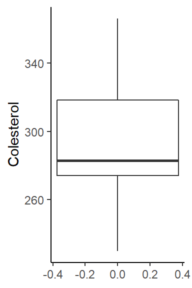

```r
library(ggplot2)
library(tidyverse)

Colesterol %>%
  as.data.frame() %>%
  ggplot(aes(y = Colesterol)) +
  geom_boxplot() +
  theme_classic()
```

## Ejercicio 2

```r
Bacterias <- c(14, 15, 13, 21, 15, 14, 26, 16, 20, 13)
summary(Bacterias)
```

```
##    Min. 1st Qu.  Median    Mean 3rd Qu.    Max.
##    13.0    14.0    15.0    16.7    19.0    26.0
```

```r
max(Bacterias) - min(Bacterias)
```

```
## [1] 13
```

```r
sd(Bacterias)
```

```
## [1] 4.270051
```

## Ejercicio 2

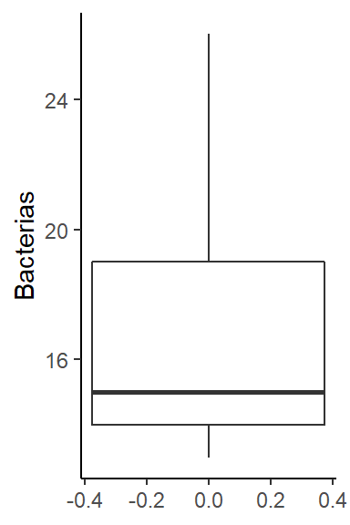

```r
Bacterias %>%
  as.data.frame() %>%
  ggplot(aes(y = Bacterias)) +
  geom_boxplot() +
  theme_classic()
```